# Has other (living) family members (e.g. parents, siblings, in-laws, etc.)

# 1 Description of DataSchema variable

The description of harmonised variables is the following:

- Short name: `oth_fam`
- Variable label: `Has other (living) family members (e.g. parents, siblings, in-laws, etc.)`
- Domain: `Social environment`
- Value type: `categorical`
- Categories:

| **Code** | **Category Label** |
| --- | --- |
| 0 | No |
| 1 | Yes |

- Category missings:

| **Code** | **Category Label** |
| --- | --- |
| 991 | CAPI/interviewer error |
| 992 | Impute |
| 993 | Disable to measure |
| 994 | Not attempt/not done |
| 995 | Does not answer |
| 996 | Not applicable |
| 997 | Refuse |
| 998 | Do not know |
| 999 | Missing |

# 2 Data process

## 2.1 England

### 2.1.1 Wave 1

#### 2.1.1.1 Study-specific variable description

The study-specific variable elected to be harmonised is:

- Name: `scfam`
- Label: `Do you have any other immediate family?`
- Categories:
  - `1 = Yes`
  - `2 = No`
- Missings:
  - `-9 = Not answered`
  - `-1 = Not applicable`
- Name: `Dinfa`
- Label: `Is your natural father still alive?`
- Categories:
  - `1 = Yes`
  - `2 = No`
- Missings:
  - `-9 = Refusal`
  - `-8 = Don't know`
  - `-1 = Not applicable`
- Name: `Dinma`
- Label: `Is your natural mother still alive?`
- Categories:
  - `1 = Yes`
  - `2 = No`
- Missings:
  - `-9 = Refusal`
  - `-8 = Don't know`
  - `-1 = Not applicable`
- Name: `Disib`
- Label: `How many living brothers or sisters do you have?`
- Missings:
  - `-9 = Refusal`
  - `-8 = Don't know`
  - `-1 = Not applicable`
- Description:

SCFAM

| Sample size | Missing values |
| --- | --- |
| 12099 | 1455 |

Category

|  | 1 | 2 |
| --- | --- | --- |
| Frequency | 9787.00 | 857.00 |
| Percentage | 80.89 | 7.08 |

Type of missing

|  | -9 | -1 | NA |
| --- | --- | --- | --- |
| Frequency | 347.00 | 1108.00 | 0 |
| Percentage | 2.87 | 9.16 | 0 |

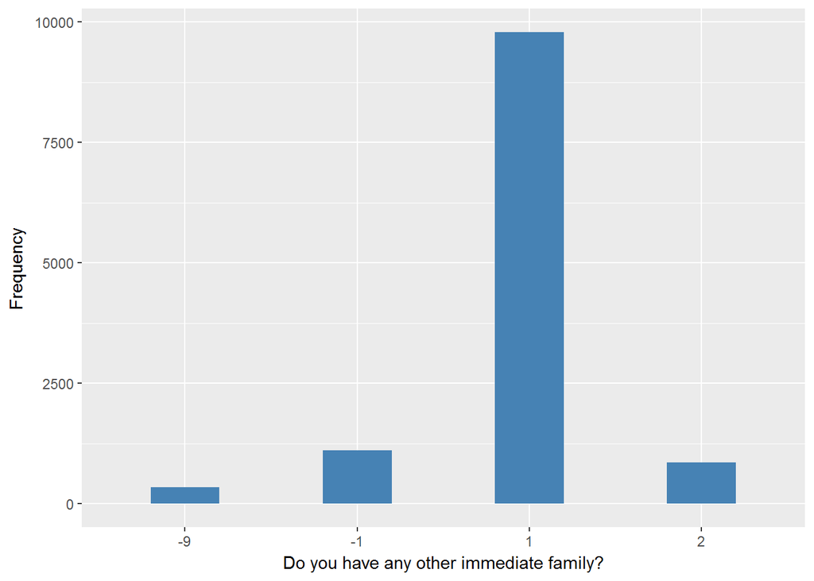

[output not shown]

Category

[output not shown]

Type of missing

[output not shown]

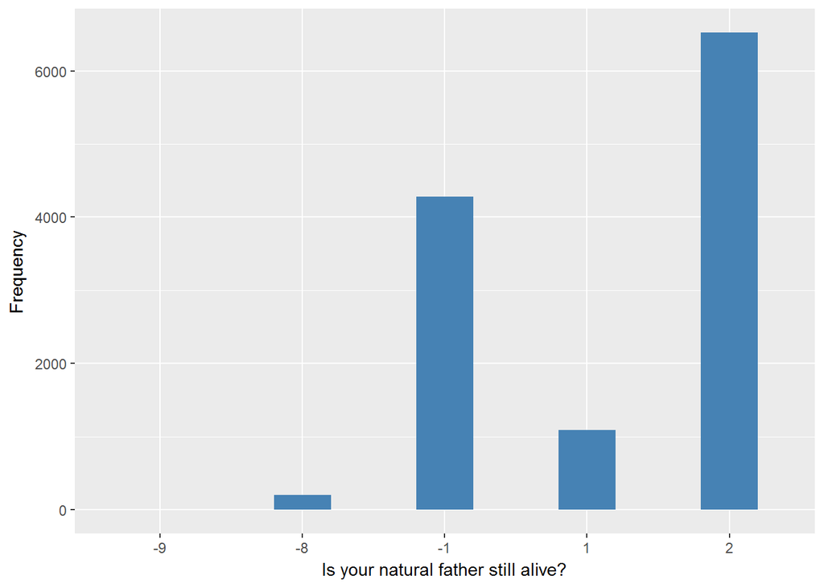

[output not shown]

Category

[output not shown]

Type of missing

[output not shown]

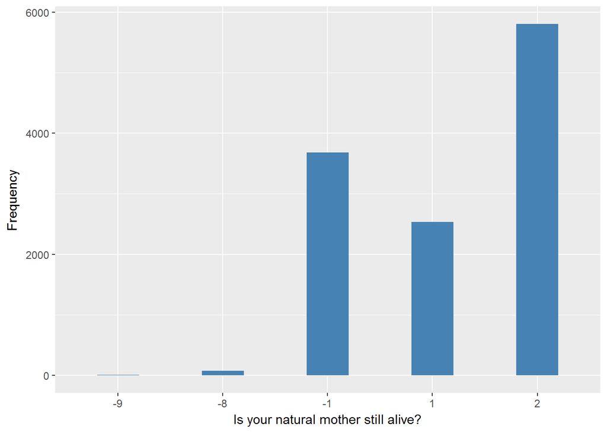

DISIB

| Sample size | Missing values |
| --- | --- |
| 12099 | 43 |

Values

|  | No-missings | -9 | -8 | -1 | NA |
| --- | --- | --- | --- | --- | --- |
| Frequency | 12056.00 | 4.00 | 39.00 | 0 | 0 |
| Percentage | 99.64 | 0.03 | 0.32 | 0 | 0 |

Summary

| Min. | 1st Qu. | Median | Mean | 3rd Qu. | Max. |
| --- | --- | --- | --- | --- | --- |
| 0 | 1 | 1 | 1.941 | 3 | 17 |

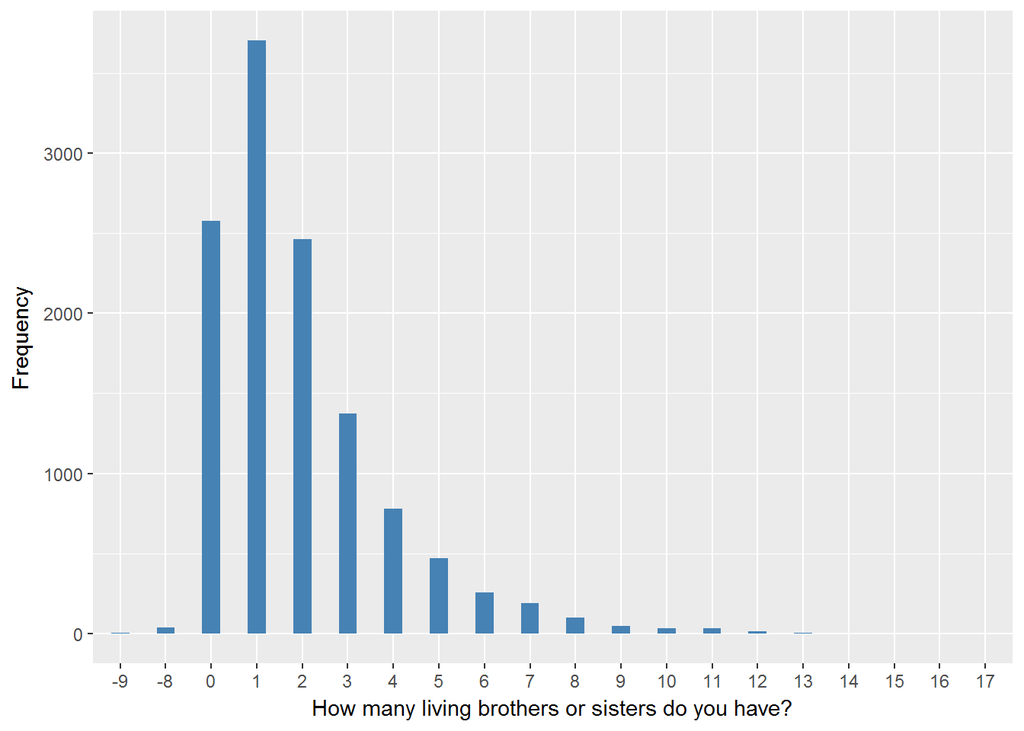

#### 2.1.1.2 Harmonisation algorithm

To compute the harmonize variable from the study-specific variable it has to be recoded as follows:

- `if any eqauls 1 or disib>0 then 1`
- `if all are equal 2 and disib=0 then 0`
- `-1 into 996`
- `-8 into 998`
- `-9 into 997, but -9 for scfam into 995`
- `NA into 999`

**R script:**

```r
ELSA_ds_w1 <- tibble(id = ELSA_w1_oth_fam$id)

ELSA_w1_oth_fam$scfam <- car::recode(as.vector(ELSA_w1_oth_fam$scfam), "NA='-999'")
ELSA_w1_oth_fam$dinfa <- car::recode(as.vector(ELSA_w1_oth_fam$dinfa), "NA='-999'")
ELSA_w1_oth_fam$dinma <- car::recode(as.vector(ELSA_w1_oth_fam$dinma), "NA='-999'")
ELSA_w1_oth_fam$disib <- car::recode(as.vector(ELSA_w1_oth_fam$disib), "NA='-999'")

ELSA_ds_w1$oth_fam <- c(NA)
for (i in 1:dim(ELSA_w1_oth_fam)[1]) {
    if (ELSA_w1_oth_fam$scfam[i] == 1 | ELSA_w1_oth_fam$dinfa[i] == 1 | ELSA_w1_oth_fam$dinma[i] ==
        1 | ELSA_w1_oth_fam$disib[i] > 0) {
        ELSA_ds_w1$oth_fam[i] = 1
    } else if (ELSA_w1_oth_fam$scfam[i] == 2 & ELSA_w1_oth_fam$dinfa[i] %in% c(2,
        -1) & ELSA_w1_oth_fam$dinma[i] %in% c(2, -1) & ELSA_w1_oth_fam$disib[i] ==
        0) {
        ELSA_ds_w1$oth_fam[i] = 0
    } else if (ELSA_w1_oth_fam$scfam[i] == -8 | ELSA_w1_oth_fam$dinfa[i] == -8 |
        ELSA_w1_oth_fam$dinma[i] == -8 | ELSA_w1_oth_fam$disib[i] == -8) {
        ELSA_ds_w1$oth_fam[i] = 998
    } else if (ELSA_w1_oth_fam$dinfa[i] == -9 | ELSA_w1_oth_fam$dinma[i] == -9 |
        ELSA_w1_oth_fam$disib[i] == -9) {
        ELSA_ds_w1$oth_fam[i] = 997
    } else if (ELSA_w1_oth_fam$scfam[i] == -9) {
        ELSA_ds_w1$oth_fam[i] = 995
    } else if (ELSA_w1_oth_fam$scfam[i] == -1 | ELSA_w1_oth_fam$dinfa[i] == -1 |
        ELSA_w1_oth_fam$dinma[i] == -1 | ELSA_w1_oth_fam$disib[i] == -1) {
        ELSA_ds_w1$oth_fam[i] = 996
    }
}

ELSA_ds_w1$oth_fam <- car::recode(as.vector(ELSA_ds_w1$oth_fam), "NA='999'")
ELSA_ds_w1$oth_fam <- labelled(ELSA_ds_w1$oth_fam, labels = c(No = 0, Yes = 1,
    Missing = 999, `Do not know` = 998, Refuse = 997, `Not applicable` = 996,
    `Don't answer` = 995, `Not attempt/not done/not yet recorded` = 994, `disable to measure` = 993,
    Impute = 992, `CAPI/interviewer error` = 991))
```

#### 2.1.1.3 Statistical description of the new harmonised variable

| Sample size | Missing values |
| --- | --- |
| 12099 | 387 |

Category

|  | 0 | 1 |
| --- | --- | --- |
| Frequency | 636.00 | 11076.00 |
| Percentage | 5.26 | 91.54 |

Type of missing

|  | 991 | 992 | 993 | 994 | 995 | 996 | 997 | 998 | 999 | NA |
| --- | --- | --- | --- | --- | --- | --- | --- | --- | --- | --- |
| Frequency | 0 | 0 | 0 | 0 | 81.00 | 242 | 4.00 | 60.0 | 0 | 0 |
| Percentage | 0 | 0 | 0 | 0 | 0.67 | 2 | 0.03 | 0.5 | 0 | 0 |

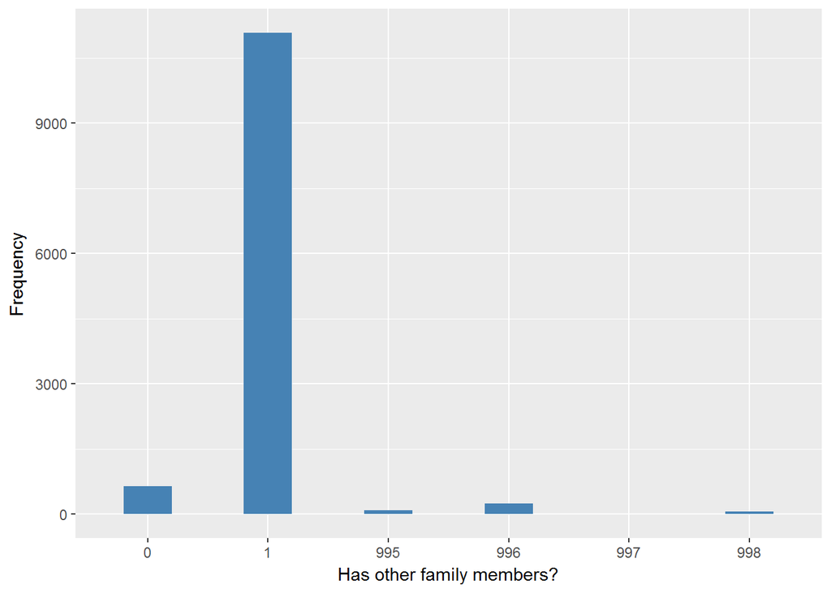

#### 2.1.1.4 Validation

### 2.1.2 Wave 2

#### 2.1.2.1 Study-specific variable description

The study-specific variable elected to be harmonised is:

- Name: `scfam`
- Label: `Whether the respondent has any other immediate family`
- Categories:
  - `1 = Yes`
  - `2 = No`
- Missings:
  - `-9 = Not answered`
  - `-1 = Item not applicable`
- Name: `DiNFA`
- Label: `Is your natural father still alive?`
- Categories:
  - `1 = Yes`
  - `2 = No`
- Missings:
  - `-9 = Refusal`
  - `-8 = Don't know`
  - `-1 = Not applicable`
- Name: `DiNMA`
- Label: `Is your natural mother still alive?`
- Categories:
  - `1 = Yes`
  - `2 = No`
- Missings:
  - `-9 = Refusal`
  - `-8 = Don't know`
  - `-1 = Not applicable`
- Name: `DiSib`
- Label: `How many living brothers or sisters do you have?`
- Missings:
  - `-9 = Refusal`
  - `-8 = Don't know`
  - `-1 = Not applicable`
- Description:

SCFAM

| Sample size | Missing values |
| --- | --- |
| 9432 | 1180 |

Category

|  | 1 | 2 |
| --- | --- | --- |
| Frequency | 7641.00 | 611.00 |
| Percentage | 81.01 | 6.48 |

Type of missing

|  | -9 | -1 | NA |
| --- | --- | --- | --- |
| Frequency | 108.00 | 1072.00 | 0 |
| Percentage | 1.15 | 11.37 | 0 |

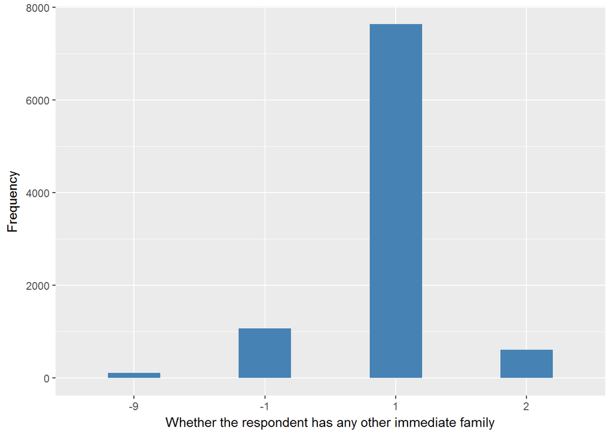

DINFA

| Sample size | Missing values |
| --- | --- |
| 9432 | 8388 |

Category

|  | 1 | 2 |
| --- | --- | --- |
| Frequency | 733.00 | 311.0 |
| Percentage | 7.77 | 3.3 |

Type of missing

|  | -9 | -8 | -1 | NA |
| --- | --- | --- | --- | --- |
| Frequency | 0 | 104.0 | 8284.00 | 0 |
| Percentage | 0 | 1.1 | 87.83 | 0 |

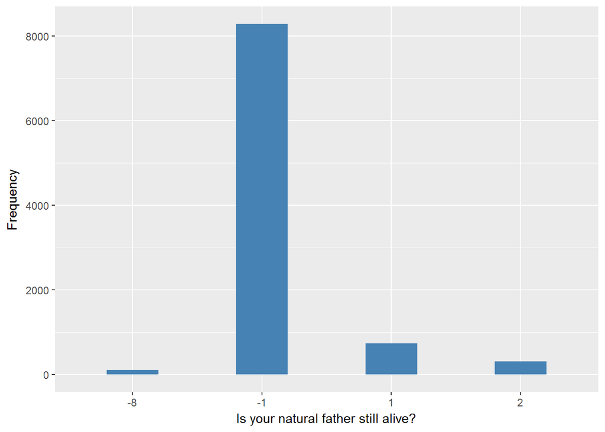

DINMA

| Sample size | Missing values |
| --- | --- |
| 9432 | 7271 |

Category

|  | 1 | 2 |
| --- | --- | --- |
| Frequency | 1726.0 | 435.00 |
| Percentage | 18.3 | 4.61 |

Type of missing

|  | -9 | -8 | -1 | NA |
| --- | --- | --- | --- | --- |
| Frequency | 0 | 34.00 | 7237.00 | 0 |
| Percentage | 0 | 0.36 | 76.73 | 0 |

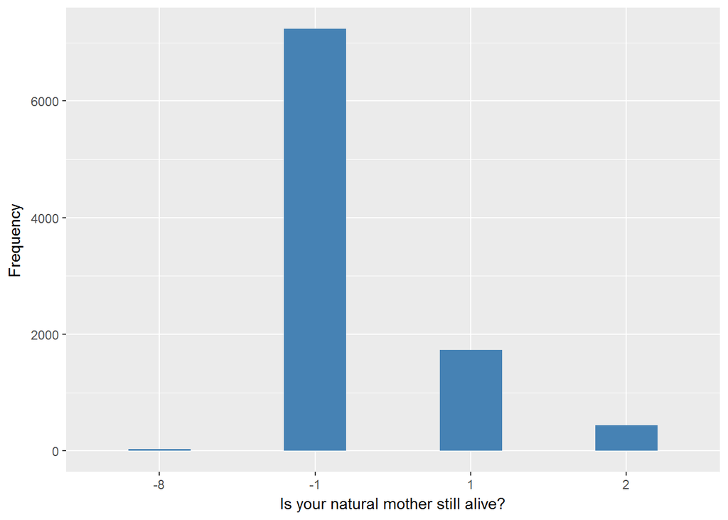

DISIB

| Sample size | Missing values |
| --- | --- |
| 9432 | 24 |

Values

|  | No-missings | -9 | -8 | -1 | NA |
| --- | --- | --- | --- | --- | --- |
| Frequency | 9408.00 | 0 | 7.00 | 17.00 | 0 |
| Percentage | 99.75 | 0 | 0.07 | 0.18 | 0 |

Summary

| Min. | 1st Qu. | Median | Mean | 3rd Qu. | Max. |
| --- | --- | --- | --- | --- | --- |
| 0 | 1 | 1 | 1.835 | 3 | 17 |

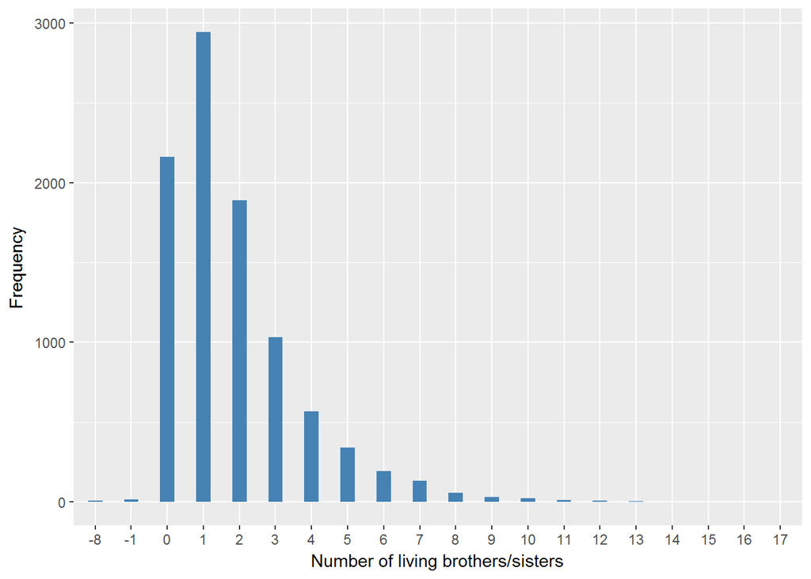

#### 2.1.2.2 Harmonisation algorithm

To recode the harmonize variable from the study-specific variable it has to be recoded as follows:

- `if any eqauls 1 or DiSib>0 then 1`
- `if all are equal 2 and DiSib=0 then 0`
- `-1 into 996`
- `-8 into 998`
- `-9 into 997, but -9 for scfam into 995`
- `NA into 999`

**R script:**

```r
ELSA_ds_w2 <- tibble(id = ELSA_w2_oth_fam$id)

ELSA_w2_oth_fam$scfam <- car::recode(as.vector(ELSA_w2_oth_fam$scfam), "NA='-999'")
ELSA_w2_oth_fam$DiNFA <- car::recode(as.vector(ELSA_w2_oth_fam$DiNFA), "NA='-999'")
ELSA_w2_oth_fam$DiNMA <- car::recode(as.vector(ELSA_w2_oth_fam$DiNMA), "NA='-999'")
ELSA_w2_oth_fam$DiSib <- car::recode(as.vector(ELSA_w2_oth_fam$DiSib), "NA='-999'")

ELSA_ds_w2$oth_fam <- c(NA)
for (i in 1:dim(ELSA_w2_oth_fam)[1]) {
    if (ELSA_w2_oth_fam$scfam[i] == 1 | ELSA_w2_oth_fam$DiNFA[i] == 1 | ELSA_w2_oth_fam$DiNMA[i] ==
        1 | ELSA_w2_oth_fam$DiSib[i] > 0) {
        ELSA_ds_w2$oth_fam[i] = 1
    } else if (ELSA_w2_oth_fam$scfam[i] == 2 & ELSA_w2_oth_fam$DiNFA[i] %in% c(2,
        -1) & ELSA_w2_oth_fam$DiNMA[i] %in% c(2, -1) & ELSA_w2_oth_fam$DiSib[i] ==
        0) {
        ELSA_ds_w2$oth_fam[i] = 0
    } else if (ELSA_w2_oth_fam$scfam[i] == -8 | ELSA_w2_oth_fam$DiNFA[i] == -8 |
        ELSA_w2_oth_fam$DiNMA[i] == -8 | ELSA_w2_oth_fam$DiSib[i] == -8) {
        ELSA_ds_w2$oth_fam[i] = 998
    } else if (ELSA_w2_oth_fam$DiNFA[i] == -9 | ELSA_w2_oth_fam$DiNMA[i] == -9 |
        ELSA_w2_oth_fam$DiSib[i] == -9) {
        ELSA_ds_w2$oth_fam[i] = 997
    } else if (ELSA_w2_oth_fam$scfam[i] == -9) {
        ELSA_ds_w2$oth_fam[i] = 995
    } else if (ELSA_w2_oth_fam$scfam[i] == -1 | ELSA_w2_oth_fam$DiNFA[i] == -1 |
        ELSA_w2_oth_fam$DiNMA[i] == -1 | ELSA_w2_oth_fam$DiSib[i] == -1) {
        ELSA_ds_w2$oth_fam[i] = 996
    }
}

ELSA_ds_w2$oth_fam <- car::recode(as.vector(ELSA_ds_w2$oth_fam), "NA='999'")
ELSA_ds_w2$oth_fam <- labelled(ELSA_ds_w2$oth_fam, labels = c(No = 0, Yes = 1,
    Missing = 999, `Do not know` = 998, Refuse = 997, `Not applicable` = 996,
    `Don't answer` = 995, `Not attempt/not done/not yet recorded` = 994, `Disable to measure` = 993,
    Impute = 992, `CAPI/interviewer error` = 991))
```

#### 2.1.2.3 Statistical description of the new harmonised variable

| Sample size | Missing values |
| --- | --- |
| 9432 | 313 |

Category

|  | 0 | 1 |
| --- | --- | --- |
| Frequency | 499.00 | 8620.00 |
| Percentage | 5.29 | 91.39 |

Type of missing

|  | 991 | 992 | 993 | 994 | 995 | 996 | 997 | 998 | 999 | NA |
| --- | --- | --- | --- | --- | --- | --- | --- | --- | --- | --- |
| Frequency | 0 | 0 | 0 | 0 | 33.00 | 257.00 | 0 | 23.00 | 0 | 0 |
| Percentage | 0 | 0 | 0 | 0 | 0.35 | 2.72 | 0 | 0.24 | 0 | 0 |

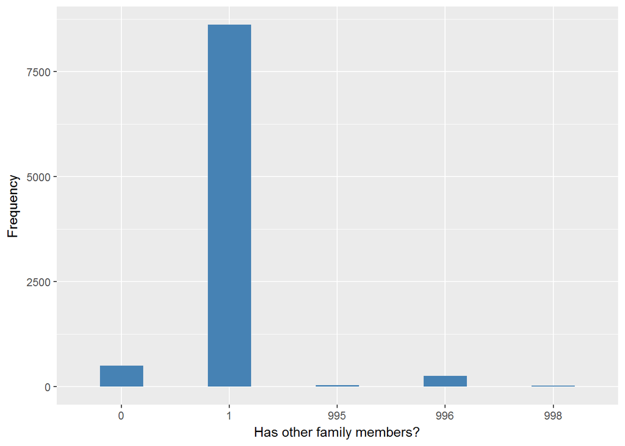

#### 2.1.2.4 Validation

### 2.1.3 Wave 3

#### 2.1.3.1 Study-specific variable description

The study-specific variable elected to be harmonised is:

- Name: `scfam`
- Label: `Whether the respondent has any other immediate family`
- Categories:
  - `1 = Yes`
  - `2 = No`
- Missings:
  - `-1 = Item not applicable`
  - `-8 = Don't know`
  - `-9 = Not answered`
- Name: `dinfa`
- Label: `Is your natural father still alive?`
- Categories:
  - `1 = Yes`
  - `2 = No`
- Missings:
  - `-9 = Refusal`
  - `-8 = Don't know`
  - `-2 = Schedule not applicable`
  - `-1 = Not applicable`
- Name: `dinma`
- Label: `Is your natural mother still alive?`
- Categories:
  - `1 = Yes`
  - `2 = No`
- Missings:
  - `-9 = Refusal`
  - `-8 = Don't know`
  - `-2 = Schedule not applicable`
  - `-1 = Not applicable`
- Name: `disib`
- Label: `Number of living brothers/sisters`
- Missings:
  - `-9 = Refusal`
  - `-8 = Don't know`
  - `-1 = Not applicable`
- Description:

SCFAM

| Sample size | Missing values |
| --- | --- |
| 9771 | 1634 |

Category

|  | 1 | 2 |
| --- | --- | --- |
| Frequency | 7539.00 | 598.00 |
| Percentage | 77.16 | 6.12 |

Type of missing

|  | -9 | -8 | -1 | NA |
| --- | --- | --- | --- | --- |
| Frequency | 107.0 | 0 | 1527.00 | 0 |
| Percentage | 1.1 | 0 | 15.63 | 0 |

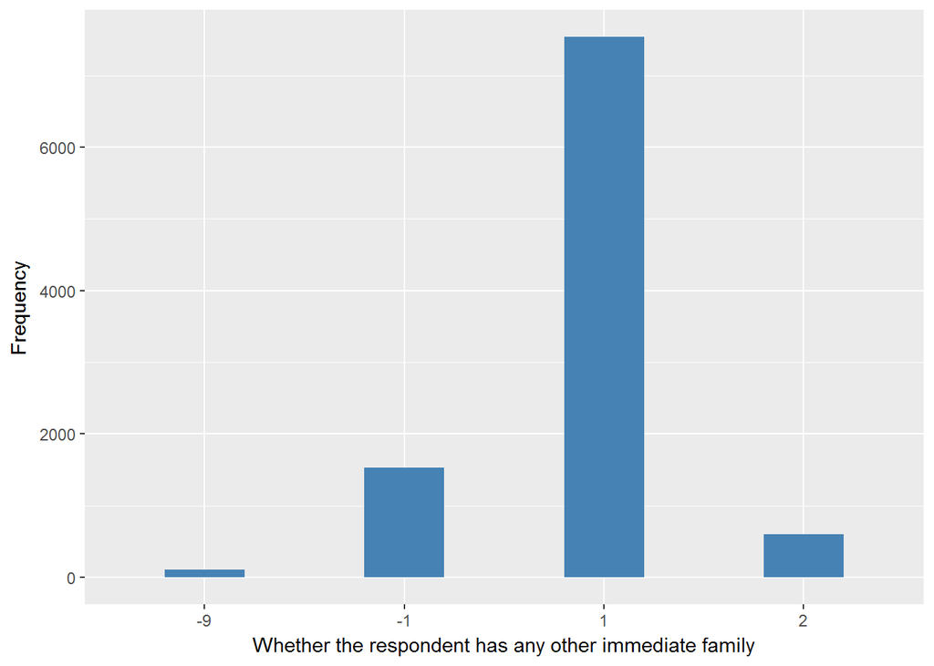

DINFA

| Sample size | Missing values |
| --- | --- |
| 9771 | 7417 |

Category

|  | 1 | 2 |
| --- | --- | --- |
| Frequency | 1059.00 | 1295.00 |
| Percentage | 10.84 | 13.25 |

Type of missing

|  | -9 | -8 | -2 | -1 | NA |
| --- | --- | --- | --- | --- | --- |
| Frequency | 1.00 | 88.0 | 0 | 7328 | 0 |
| Percentage | 0.01 | 0.9 | 0 | 75 | 0 |

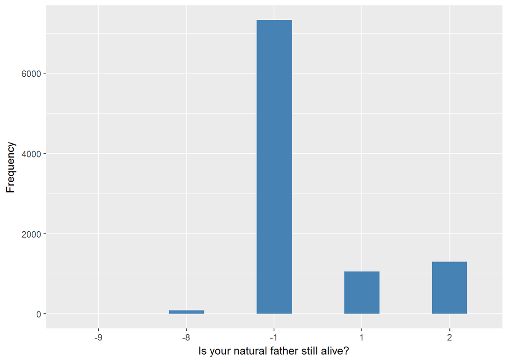

DINMA

| Sample size | Missing values |
| --- | --- |
| 9771 | 6536 |

Category

|  | 1 | 2 |
| --- | --- | --- |
| Frequency | 2180.00 | 1055.0 |
| Percentage | 22.31 | 10.8 |

Type of missing

|  | -9 | -8 | -2 | -1 | NA |
| --- | --- | --- | --- | --- | --- |
| Frequency | 0 | 33.00 | 0 | 6503.00 | 0 |
| Percentage | 0 | 0.34 | 0 | 66.55 | 0 |

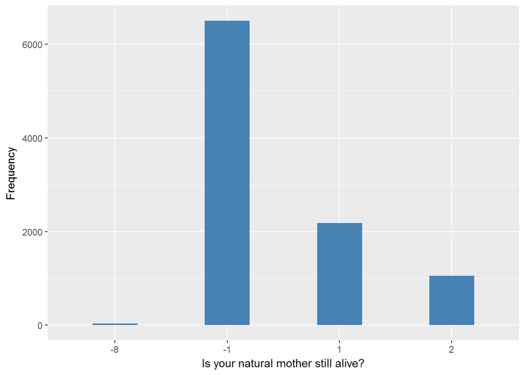

DISIB

| Sample size | Missing values |
| --- | --- |
| 9771 | 36 |

Values

|  | No-missings | -9 | -8 | -1 | NA |
| --- | --- | --- | --- | --- | --- |
| Frequency | 9735.00 | 0 | 15.00 | 21.00 | 0 |
| Percentage | 99.63 | 0 | 0.15 | 0.21 | 0 |

Summary

| Min. | 1st Qu. | Median | Mean | 3rd Qu. | Max. |
| --- | --- | --- | --- | --- | --- |
| 0 | 1 | 1 | 1.886 | 3 | 17 |

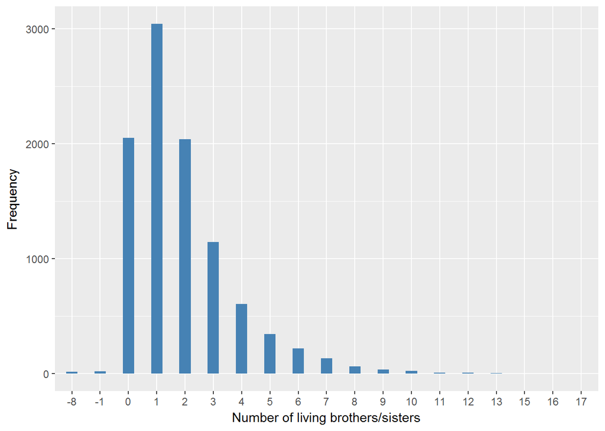

#### 2.1.3.2 Harmonisation algorithm

To recode the harmonize variable from the study-specific variable it has to be recoded as follows:

- `if any eqauls 1 or disib>0 then 1`
- `if all are equal 2 and disib=0 then 0`
- `-1 into 996`
- `-2 into 996`
- `-8 into 998`
- `-9 into 997, but -9 for scfam into 995`
- `NA into 999`

**R script:**

```r
ELSA_ds_w3 <- tibble(id = ELSA_w3_oth_fam$id)

ELSA_w3_oth_fam$scfam <- car::recode(as.vector(ELSA_w3_oth_fam$scfam), "NA='-999'")
ELSA_w3_oth_fam$dinfa <- car::recode(as.vector(ELSA_w3_oth_fam$dinfa), "NA='-999'")
ELSA_w3_oth_fam$dinma <- car::recode(as.vector(ELSA_w3_oth_fam$dinma), "NA='-999'")
ELSA_w3_oth_fam$disib <- car::recode(as.vector(ELSA_w3_oth_fam$disib), "NA='-999'")

ELSA_ds_w3$oth_fam <- c(NA)
for (i in 1:dim(ELSA_w3_oth_fam)[1]) {
    if (ELSA_w3_oth_fam$scfam[i] == 1 | ELSA_w3_oth_fam$dinfa[i] == 1 | ELSA_w3_oth_fam$dinma[i] ==
        1 | ELSA_w3_oth_fam$disib[i] > 0) {
        ELSA_ds_w3$oth_fam[i] = 1
    } else if (ELSA_w3_oth_fam$scfam[i] == 2 & ELSA_w3_oth_fam$dinfa[i] %in% c(2,
        -1) & ELSA_w3_oth_fam$dinma[i] %in% c(2, -1) & ELSA_w3_oth_fam$disib[i] ==
        0) {
        ELSA_ds_w3$oth_fam[i] = 0
    } else if (ELSA_w3_oth_fam$scfam[i] == -8 | ELSA_w3_oth_fam$dinfa[i] == -8 |
        ELSA_w3_oth_fam$dinma[i] == -8 | ELSA_w3_oth_fam$disib[i] == -8) {
        ELSA_ds_w3$oth_fam[i] = 998
    } else if (ELSA_w3_oth_fam$dinfa[i] == -2 | ELSA_w3_oth_fam$dinma[i] == -2) {
        ELSA_ds_w3$oth_fam[i] = 996
    } else if (ELSA_w3_oth_fam$dinfa[i] == -9 | ELSA_w3_oth_fam$dinma[i] == -9 |
        ELSA_w3_oth_fam$disib[i] == -9) {
        ELSA_ds_w3$oth_fam[i] = 997
    } else if (ELSA_w3_oth_fam$scfam[i] == -9) {
        ELSA_ds_w3$oth_fam[i] = 995
    } else if (ELSA_w3_oth_fam$scfam[i] == -1 | ELSA_w3_oth_fam$dinfa[i] == -1 |
        ELSA_w3_oth_fam$dinma[i] == -1 | ELSA_w3_oth_fam$disib[i] == -1) {
        ELSA_ds_w3$oth_fam[i] = 996
    }
}

ELSA_ds_w3$oth_fam <- car::recode(as.vector(ELSA_ds_w3$oth_fam), "NA='999'")
ELSA_ds_w3$oth_fam <- labelled(ELSA_ds_w3$oth_fam, labels = c(No = 0, Yes = 1,
    Missing = 999, `Do not know` = 998, Refuse = 997, `Not applicable` = 996,
    `Don't answer` = 995, `Not attempt/not done/not yet recorded` = 994, `Disable to measure` = 993,
    Impute = 992, `CAPI/interviewer error` = 991))
```

#### 2.1.3.3 Statistical description of the new harmonised variable

| Sample size | Missing values |
| --- | --- |
| 9771 | 376 |

Category

|  | 0 | 1 |
| --- | --- | --- |
| Frequency | 478.00 | 8917.00 |
| Percentage | 4.89 | 91.26 |

Type of missing

|  | 991 | 992 | 993 | 994 | 995 | 996 | 997 | 998 | 999 | NA |
| --- | --- | --- | --- | --- | --- | --- | --- | --- | --- | --- |
| Frequency | 0 | 0 | 0 | 0 | 30.00 | 323.00 | 0 | 23.00 | 0 | 0 |
| Percentage | 0 | 0 | 0 | 0 | 0.31 | 3.31 | 0 | 0.24 | 0 | 0 |

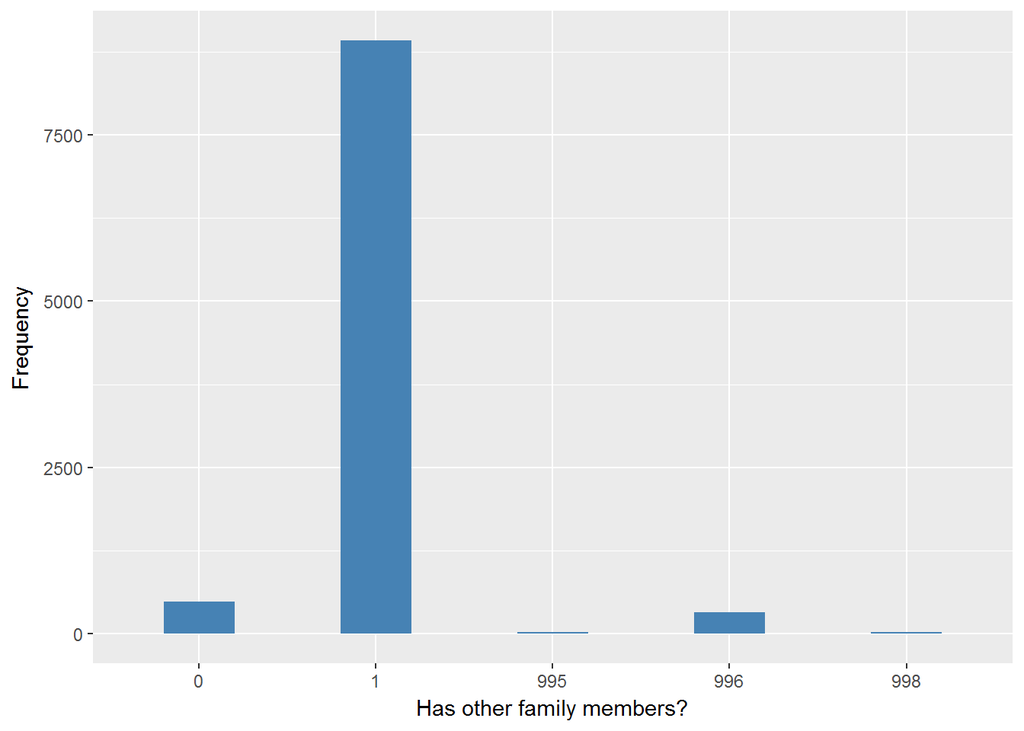

##### 2.1.3.3.1 Validation

### 2.1.4 Wave 4

#### 2.1.4.1 Study-specific variable description

The study-specific variable elected to be harmonised is:

- Name: `scfam`
- Label: `Whether the respondent has any other immediate family`
- Categories:
  - `1 = Yes`
  - `2 = No`
- Missings:
  - `-1 = Item not applicable`
  - `-8 = Don't know`
  - `-9 = Not answered`
- Name: `dinfa`
- Label: `Is your natural father still alive?`
- Categories:
  - `1 = Yes`
  - `2 = No`
- Missings:
  - `-9 = Refusal`
  - `-8 = Don't know`
  - `-2 = Capi/Interview Error`
  - `-1 = Not applicable`
- Name: `dinma`
- Label: `Is your natural mother still alive?`
- Categories:
  - `1 = Yes`
  - `2 = No`
- Missings:
  - `-9 = Refusal`
  - `-8 = Don't know`
  - `-2 = Capi/Interview Error`
  - `-1 = Not applicable`
- Name: `disib`
- Label: `Number of living brothers/sisters`
- Missings:
  - `-9 = Refusal`
  - `-8 = Don't know`
  - `-2 = Capi/Interview Error`
  - `-1 = Not applicable`
- Description:

SCFAM

| Sample size | Missing values |
| --- | --- |
| 11050 | 1827 |

Category

|  | 1 | 2 |
| --- | --- | --- |
| Frequency | 8556.00 | 667.00 |
| Percentage | 77.43 | 6.04 |

Type of missing

|  | -9 | -8 | -1 | NA |
| --- | --- | --- | --- | --- |
| Frequency | 119.00 | 0 | 1708.00 | 0 |
| Percentage | 1.08 | 0 | 15.46 | 0 |

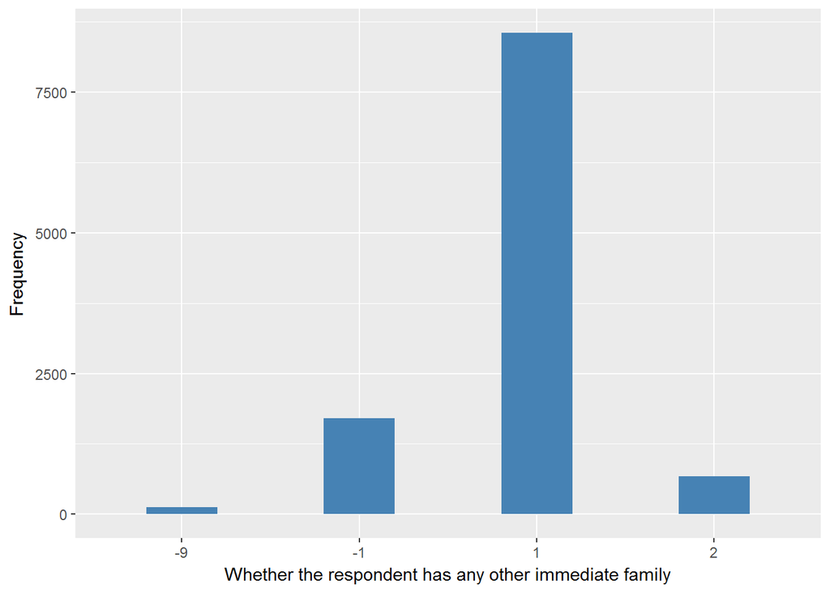

DINFA

| Sample size | Missing values |
| --- | --- |
| 11050 | 9042 |

Category

|  | 1 | 2 |
| --- | --- | --- |
| Frequency | 1058.00 | 950.0 |
| Percentage | 9.57 | 8.6 |

Type of missing

|  | -9 | -8 | -2 | -1 | NA |
| --- | --- | --- | --- | --- | --- |
| Frequency | 2.00 | 96.00 | 72.00 | 8872.00 | 0 |
| Percentage | 0.02 | 0.87 | 0.65 | 80.29 | 0 |

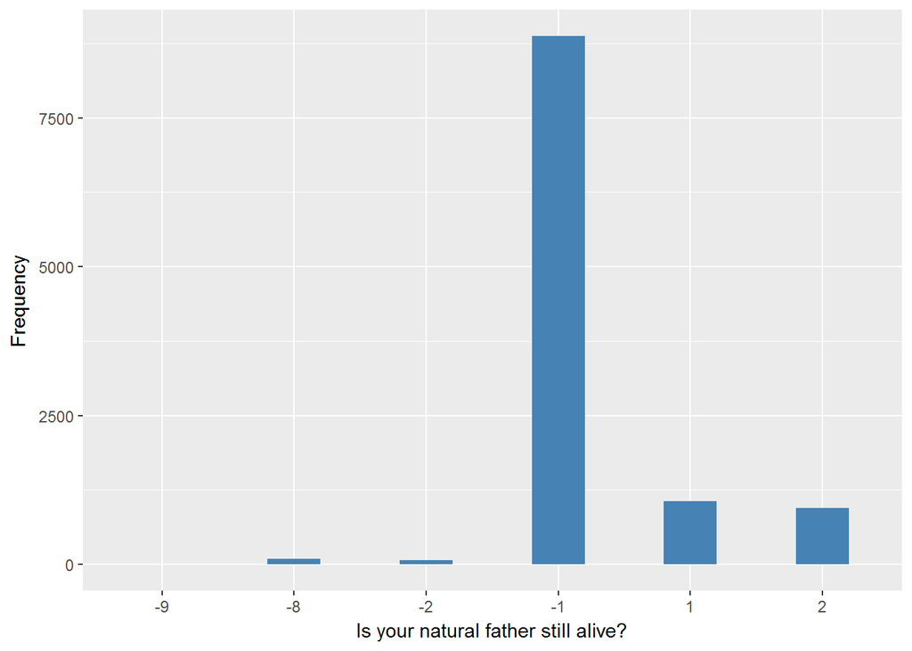

DINMA

| Sample size | Missing values |
| --- | --- |
| 11050 | 7783 |

Category

|  | 1 | 2 |
| --- | --- | --- |
| Frequency | 2258.00 | 1009.00 |
| Percentage | 20.43 | 9.13 |

Type of missing

|  | -9 | -8 | -2 | -1 | NA |
| --- | --- | --- | --- | --- | --- |
| Frequency | 2.00 | 41.00 | 72.00 | 7668.00 | 0 |
| Percentage | 0.02 | 0.37 | 0.65 | 69.39 | 0 |

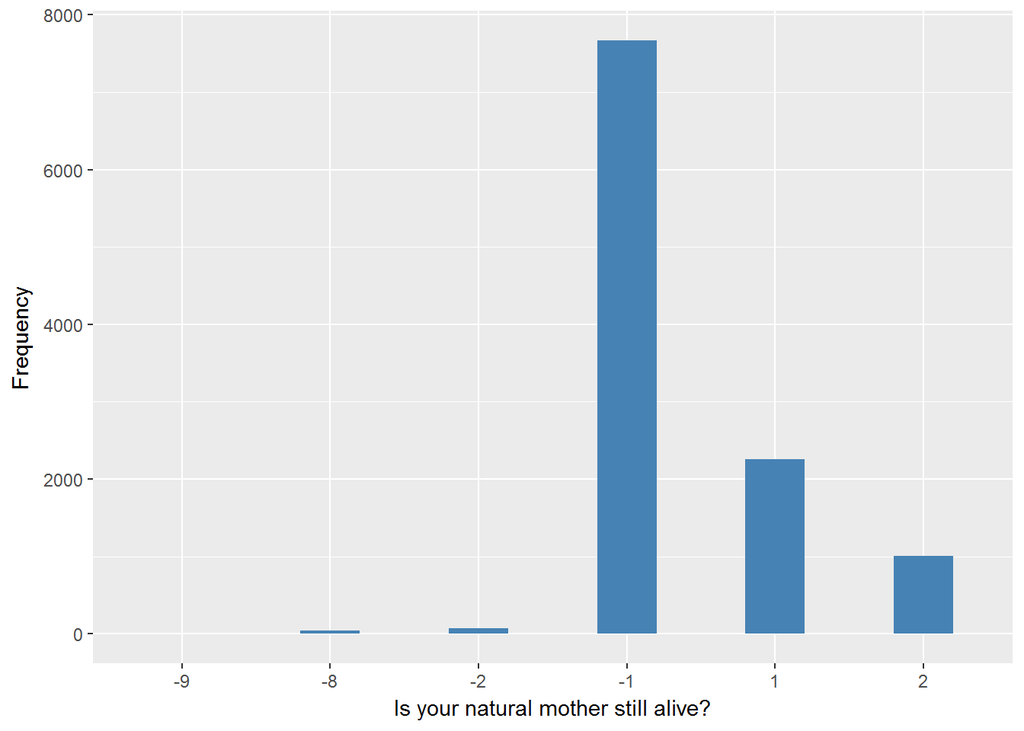

DISIB

| Sample size | Missing values |
| --- | --- |
| 11050 | 107 |

Values

|  | No-missings | -9 | -8 | -2 | -1 | NA |
| --- | --- | --- | --- | --- | --- | --- |
| Frequency | 10943.00 | 2.00 | 15.00 | 72.00 | 18.00 | 0 |
| Percentage | 99.03 | 0.02 | 0.14 | 0.65 | 0.16 | 0 |

Summary

| Min. | 1st Qu. | Median | Mean | 3rd Qu. | Max. |
| --- | --- | --- | --- | --- | --- |
| 0 | 1 | 1 | 1.878 | 3 | 17 |

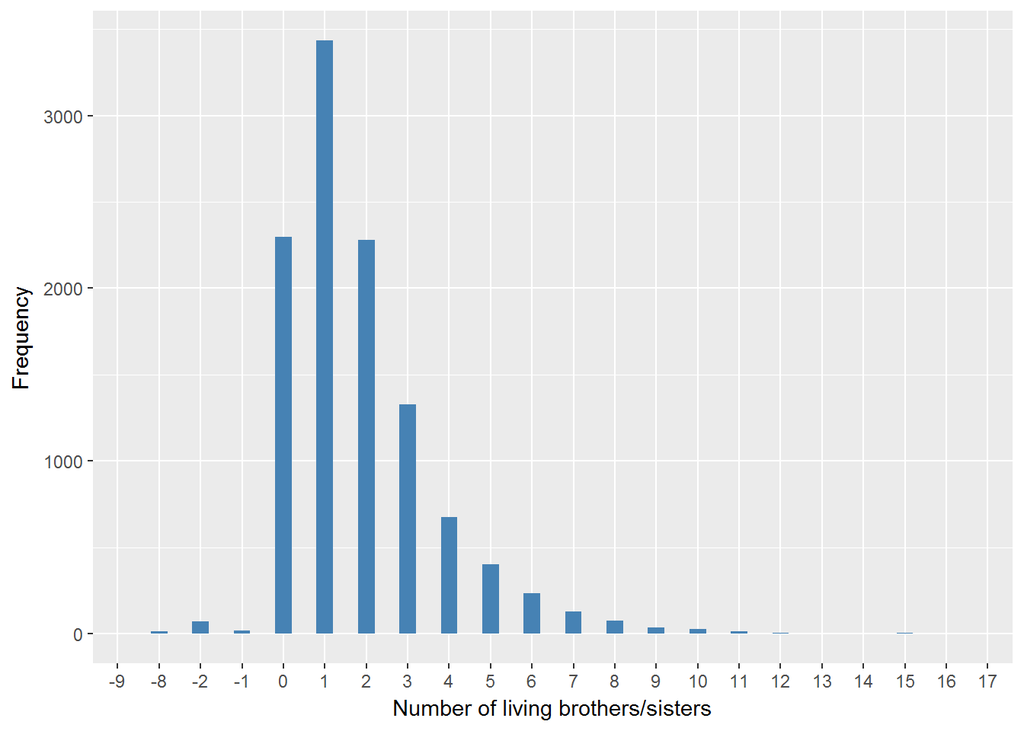

#### 2.1.4.2 Harmonisation algorithm

To recode the harmonize variable from the study-specific variable it has to be recoded as follows:

- `if any eqauls 1 or disib>0 then 1`
- `if all are equal 2 and disib=0 then 0`
- `-1 into 996`
- `-2 into 991`
- `-8 into 998`
- `-9 into 997, but -9 for scfam into 995`
- `NA into 999`

**R script:**

```r
ELSA_ds_w4 <- tibble(id = ELSA_w4_oth_fam$id)

ELSA_w4_oth_fam$scfam <- car::recode(as.vector(ELSA_w4_oth_fam$scfam), "NA='-999'")
ELSA_w4_oth_fam$dinfa <- car::recode(as.vector(ELSA_w4_oth_fam$dinfa), "NA='-999'")
ELSA_w4_oth_fam$dinma <- car::recode(as.vector(ELSA_w4_oth_fam$dinma), "NA='-999'")
ELSA_w4_oth_fam$disib <- car::recode(as.vector(ELSA_w4_oth_fam$disib), "NA='-999'")

ELSA_ds_w4$oth_fam <- c(NA)
for (i in 1:dim(ELSA_w4_oth_fam)[1]) {
    if (ELSA_w4_oth_fam$scfam[i] == 1 | ELSA_w4_oth_fam$dinfa[i] == 1 | ELSA_w4_oth_fam$dinma[i] ==
        1 | ELSA_w4_oth_fam$disib[i] > 0) {
        ELSA_ds_w4$oth_fam[i] = 1
    } else if (ELSA_w4_oth_fam$scfam[i] == 2 & ELSA_w4_oth_fam$dinfa[i] %in% c(2,
        -1) & ELSA_w4_oth_fam$dinma[i] %in% c(2, -1) & ELSA_w4_oth_fam$disib[i] ==
        0) {
        ELSA_ds_w4$oth_fam[i] = 0
    } else if (ELSA_w4_oth_fam$scfam[i] == -8 | ELSA_w4_oth_fam$dinfa[i] == -8 |
        ELSA_w4_oth_fam$dinma[i] == -8 | ELSA_w4_oth_fam$disib[i] == -8) {
        ELSA_ds_w4$oth_fam[i] = 998
    } else if (ELSA_w4_oth_fam$dinfa[i] == -2 | ELSA_w4_oth_fam$dinma[i] == -2 |
        ELSA_w4_oth_fam$disib[i] == -2) {
        ELSA_ds_w4$oth_fam[i] = 991
    } else if (ELSA_w4_oth_fam$dinfa[i] == -9 | ELSA_w4_oth_fam$dinma[i] == -9 |
        ELSA_w4_oth_fam$disib[i] == -9) {
        ELSA_ds_w4$oth_fam[i] = 997
    } else if (ELSA_w4_oth_fam$scfam[i] == -9) {
        ELSA_ds_w4$oth_fam[i] = 995
    } else if (ELSA_w4_oth_fam$scfam[i] == -1 | ELSA_w4_oth_fam$dinfa[i] == -1 |
        ELSA_w4_oth_fam$dinma[i] == -1 | ELSA_w4_oth_fam$disib[i] == -1) {
        ELSA_ds_w4$oth_fam[i] = 996
    }
}

ELSA_ds_w4$oth_fam <- car::recode(as.vector(ELSA_ds_w4$oth_fam), "NA='999'")
ELSA_ds_w4$oth_fam <- labelled(ELSA_ds_w4$oth_fam, labels = c(No = 0, Yes = 1,
    Missing = 999, `Do not know` = 998, Refuse = 997, `Not applicable` = 996,
    `Don't answer` = 995, `Not attempt/not done/not yet recorded` = 994, `Disable to measure` = 993,
    Impute = 992, `CAPI/interviewer error` = 991))
```

#### 2.1.4.3 Statistical description of the new harmonised variable

| Sample size | Missing values |
| --- | --- |
| 11050 | 426 |

Category

|  | 0 | 1 |
| --- | --- | --- |
| Frequency | 540.00 | 10084.00 |
| Percentage | 4.89 | 91.26 |

Type of missing

|  | 991 | 992 | 993 | 994 | 995 | 996 | 997 | 998 | 999 | NA |
| --- | --- | --- | --- | --- | --- | --- | --- | --- | --- | --- |
| Frequency | 13.00 | 0 | 0 | 0 | 41.00 | 344.00 | 2.00 | 26.00 | 0 | 0 |
| Percentage | 0.12 | 0 | 0 | 0 | 0.37 | 3.11 | 0.02 | 0.24 | 0 | 0 |

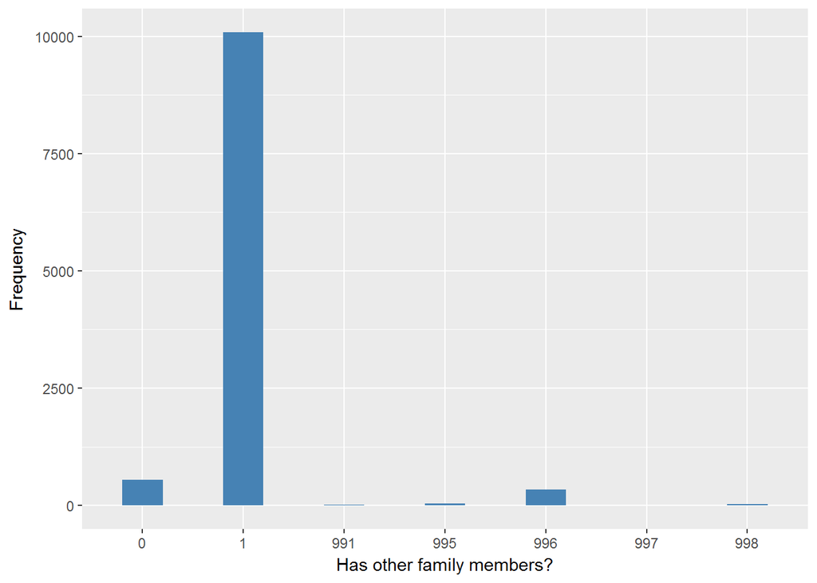

#### 2.1.4.4 Validation

### 2.1.5 Wave 5

#### 2.1.5.1 Study-specific variable description

The study-specific variable elected to be harmonised is:

- Name: `scfam`
- Label: `Whether the respondent has any other immediate family`
- Categories:
  - `1 = Yes`
  - `2 = No`
- Missings:
  - `-1 = Item not applicable`
  - `-2 = Schedule not applicable`
  - `-8 = Don't know`
  - `-9 = Not answered`
- Name: `dinfa`
- Label: `Is your natural father still alive?`
- Categories:
  - `1 = Yes`
  - `2 = No`
- Missings:
  - `-9 = Refusal`
  - `-8 = Don't know`
  - `-2 = Schedule not applicable`
  - `-1 = Not applicable`
- Name: `dinma`
- Label: `Is your natural mother still alive?`
- Categories:
  - `1 = Yes`
  - `2 = No`
- Missings:
  - `-9 = Refusal`
  - `-8 = Don't know`
  - `-2 = Schedule not applicable`
  - `-1 = Not applicable`
- Name: `disib`
- Label: `Number of living brothers/sisters`
- Missings:
  - `-9 = Refusal`
  - `-8 = Don't know`
  - `-1 = Not applicable`
- Description:

SCFAM

| Sample size | Missing values |
| --- | --- |
| 10274 | 1360 |

Category

|  | 1 | 2 |
| --- | --- | --- |
| Frequency | 8282.00 | 632.00 |
| Percentage | 80.61 | 6.15 |

Type of missing

|  | -9 | -8 | -2 | -1 | NA |
| --- | --- | --- | --- | --- | --- |
| Frequency | 116.00 | 0 | 1244.00 | 0 | 0 |
| Percentage | 1.13 | 0 | 12.11 | 0 | 0 |

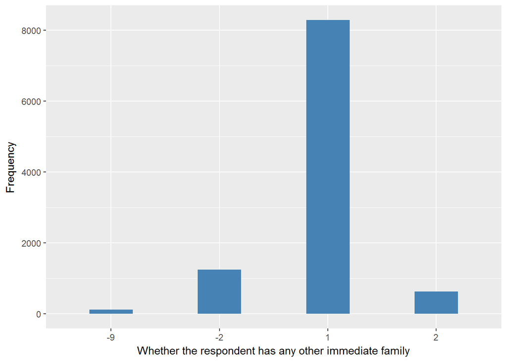

DINFA

| Sample size | Missing values |
| --- | --- |
| 10274 | 8905 |

Category

|  | 1 | 2 |
| --- | --- | --- |
| Frequency | 809.00 | 560.00 |
| Percentage | 7.87 | 5.45 |

Type of missing

|  | -9 | -8 | -2 | -1 | NA |
| --- | --- | --- | --- | --- | --- |
| Frequency | 3.00 | 74.00 | 0 | 8828.00 | 0 |
| Percentage | 0.03 | 0.72 | 0 | 85.93 | 0 |

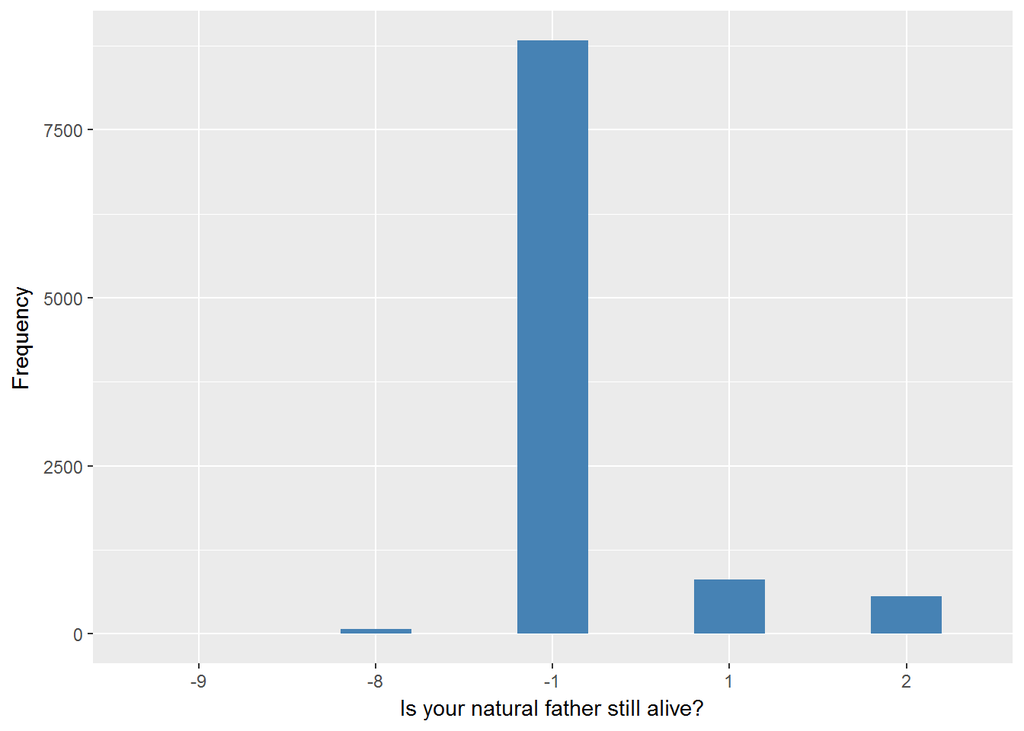

DINMA

| Sample size | Missing values |
| --- | --- |
| 10274 | 7791 |

Category

|  | 1 | 2 |
| --- | --- | --- |
| Frequency | 1853.00 | 630.00 |
| Percentage | 18.04 | 6.13 |

Type of missing

|  | -9 | -8 | -2 | -1 | NA |
| --- | --- | --- | --- | --- | --- |
| Frequency | 3.00 | 32.00 | 0 | 7756.00 | 0 |
| Percentage | 0.03 | 0.31 | 0 | 75.49 | 0 |

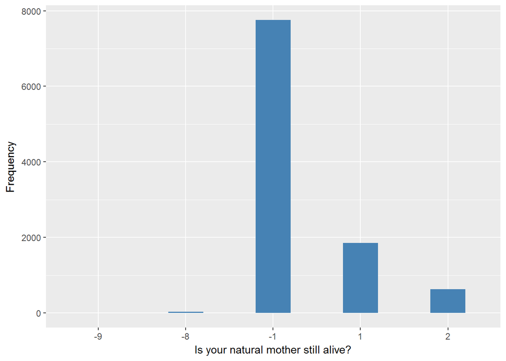

DISIB

| Sample size | Missing values |
| --- | --- |
| 10274 | 43 |

Values

|  | No-missings | -9 | -8 | -1 | NA |
| --- | --- | --- | --- | --- | --- |
| Frequency | 10231.00 | 2.00 | 9.00 | 32.00 | 0 |
| Percentage | 99.58 | 0.02 | 0.09 | 0.31 | 0 |

Summary

| Min. | 1st Qu. | Median | Mean | 3rd Qu. | Max. |
| --- | --- | --- | --- | --- | --- |
| 0 | 1 | 1 | 1.831 | 3 | 17 |

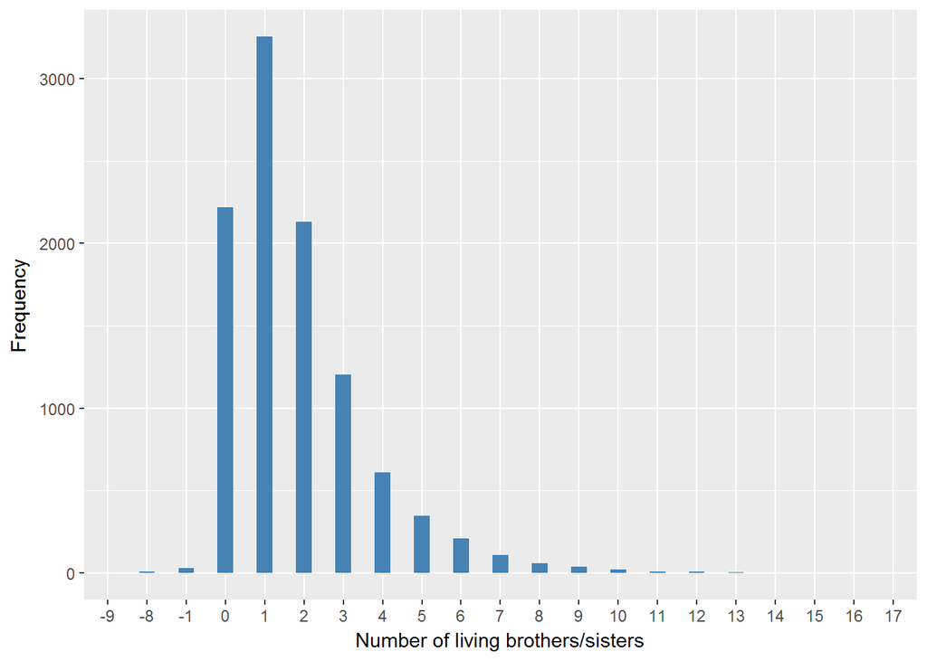

#### 2.1.5.2 Harmonisation algorithm

To recode the harmonize variable from the study-specific variable it has to be recoded as follows:

- `if any eqauls 1 or disib>0 then 1`
- `if all are equal 2 and disib=0 then 0`
- `-1 or -2 into 996`
- `-8 into 998`
- `-9 into 997, but -9 for scfam into 995`
- `NA into 999`

**R script:**

```r
ELSA_ds_w5 <- tibble(id = ELSA_w5_oth_fam$id)

ELSA_w5_oth_fam$scfam <- car::recode(as.vector(ELSA_w5_oth_fam$scfam), "NA='-999'")
ELSA_w5_oth_fam$dinfa <- car::recode(as.vector(ELSA_w5_oth_fam$dinfa), "NA='-999'")
ELSA_w5_oth_fam$dinma <- car::recode(as.vector(ELSA_w5_oth_fam$dinma), "NA='-999'")
ELSA_w5_oth_fam$disib <- car::recode(as.vector(ELSA_w5_oth_fam$disib), "NA='-999'")

ELSA_ds_w5$oth_fam <- c(NA)
for (i in 1:dim(ELSA_w5_oth_fam)[1]) {
    if (ELSA_w5_oth_fam$scfam[i] == 1 | ELSA_w5_oth_fam$dinfa[i] == 1 | ELSA_w5_oth_fam$dinma[i] ==
        1 | ELSA_w5_oth_fam$disib[i] > 0) {
        ELSA_ds_w5$oth_fam[i] = 1
    } else if (ELSA_w5_oth_fam$scfam[i] == 2 & ELSA_w5_oth_fam$dinfa[i] %in% c(2,
        -1) & ELSA_w5_oth_fam$dinma[i] %in% c(2, -1) & ELSA_w5_oth_fam$disib[i] ==
        0) {
        ELSA_ds_w5$oth_fam[i] = 0
    } else if (ELSA_w5_oth_fam$scfam[i] == -8 | ELSA_w5_oth_fam$dinfa[i] == -8 |
        ELSA_w5_oth_fam$dinma[i] == -8 | ELSA_w5_oth_fam$disib[i] == -8) {
        ELSA_ds_w5$oth_fam[i] = 998
    } else if (ELSA_w5_oth_fam$scfam[i] == -2 | ELSA_w5_oth_fam$dinfa[i] == -2 |
        ELSA_w5_oth_fam$dinma[i] == -2 | ELSA_w5_oth_fam$disib[i] == -2) {
        ELSA_ds_w5$oth_fam[i] = 996
    } else if (ELSA_w5_oth_fam$dinfa[i] == -9 | ELSA_w5_oth_fam$dinma[i] == -9 |
        ELSA_w5_oth_fam$disib[i] == -9) {
        ELSA_ds_w5$oth_fam[i] = 997
    } else if (ELSA_w5_oth_fam$scfam[i] == -9) {
        ELSA_ds_w5$oth_fam[i] = 995
    } else if (ELSA_w5_oth_fam$scfam[i] == -1 | ELSA_w5_oth_fam$dinfa[i] == -1 |
        ELSA_w5_oth_fam$dinma[i] == -1 | ELSA_w5_oth_fam$disib[i] == -1) {
        ELSA_ds_w5$oth_fam[i] = 996
    }
}

ELSA_ds_w5$oth_fam <- car::recode(as.vector(ELSA_ds_w5$oth_fam), "NA='999'")
ELSA_ds_w5$oth_fam <- labelled(ELSA_ds_w5$oth_fam, labels = c(No = 0, Yes = 1,
    Missing = 999, `Do not know` = 998, Refuse = 997, `Not applicable` = 996,
    `Don't answer` = 995, `Not attempt/not done/not yet recorded` = 994, `Disable to measure` = 993,
    Impute = 992, `CAPI/interviewer error` = 991))
```

#### 2.1.5.3 Statistical description of the new harmonised variable

| Sample size | Missing values |
| --- | --- |
| 10274 | 350 |

Category

|  | 0 | 1 |
| --- | --- | --- |
| Frequency | 529.00 | 9395.00 |
| Percentage | 5.15 | 91.44 |

Type of missing

|  | 991 | 992 | 993 | 994 | 995 | 996 | 997 | 998 | 999 | NA |
| --- | --- | --- | --- | --- | --- | --- | --- | --- | --- | --- |
| Frequency | 0 | 0 | 0 | 0 | 34.00 | 299.00 | 0 | 17.00 | 0 | 0 |
| Percentage | 0 | 0 | 0 | 0 | 0.33 | 2.91 | 0 | 0.17 | 0 | 0 |

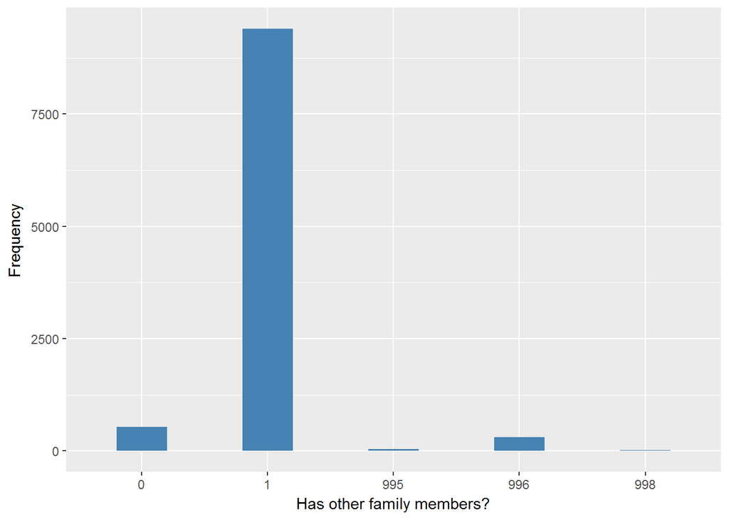

#### 2.1.5.4 Validation

### 2.1.6 Wave 6

#### 2.1.6.1 Study-specific variable description

The study-specific variable elected to be harmonised is:

- Name: `scfam`
- Label: `Whether the respondent has any other immediate family`
- Categories:
  - `1 = Yes`
  - `2 = No`
- Missings:
  - `-1 = Item not applicable`
  - `-2 = Schedule not applicable`
  - `-8 = Don't know`
  - `-9 = Not answered`
- Name: `DiNFA`
- Label: `Is your natural father still alive?`
- Categories:
  - `1 = Yes`
  - `2 = No`
- Missings:
  - `-9 = Refusal`
  - `-8 = Don't know`
  - `-2 = Schedule not applicable`
  - `-1 = Not applicable`
- Name: `DiNMA`
- Label: `Is your natural mother still alive?`
- Categories:
  - `1 = Yes`
  - `2 = No`
- Missings:
  - `-9 = Refusal`
  - `-8 = Don't know`
  - `-2 = Schedule not applicable`
  - `-1 = Not applicable`
- Name: `DiSib`
- Label: `Number of living brothers/sisters`
- Missings:
  - `-9 = Refusal`
  - `-8 = Don't know`
  - `-2 = Schedule not applicable`
  - `-1 = Not applicable`
- Description:

SCFAM

| Sample size | Missing values |
| --- | --- |
| 10601 | 1652 |

Category

|  | 1 | 2 |
| --- | --- | --- |
| Frequency | 8324.00 | 625.0 |
| Percentage | 78.52 | 5.9 |

Type of missing

|  | -9 | -8 | -2 | -1 | NA |
| --- | --- | --- | --- | --- | --- |
| Frequency | 48.00 | 0 | 1604.00 | 0 | 0 |
| Percentage | 0.45 | 0 | 15.13 | 0 | 0 |

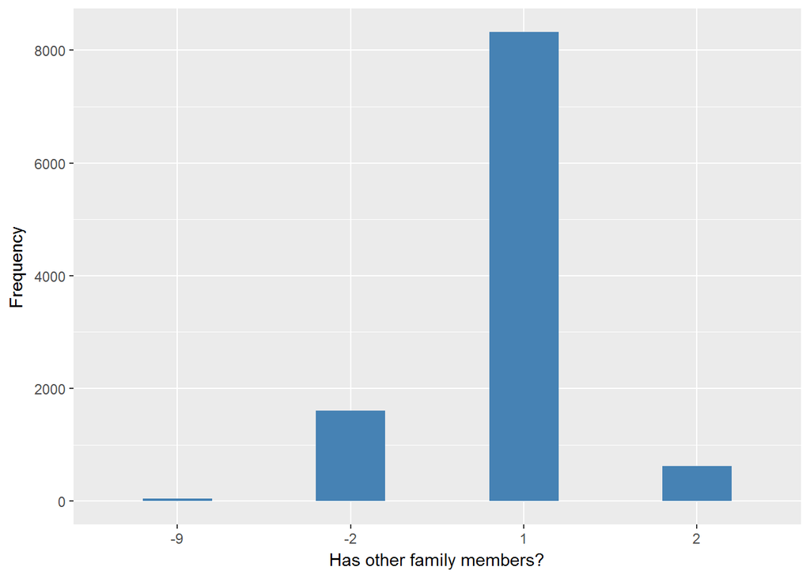

DINMA

| Sample size | Missing values |
| --- | --- |
| 10601 | 7507 |

Category

|  | 1 | 2 |
| --- | --- | --- |
| Frequency | 2113.00 | 981.00 |
| Percentage | 19.93 | 9.25 |

Type of missing

|  | -9 | -8 | -2 | -1 | NA |
| --- | --- | --- | --- | --- | --- |
| Frequency | 0 | 30.00 | 0 | 7477.00 | 0 |
| Percentage | 0 | 0.28 | 0 | 70.53 | 0 |

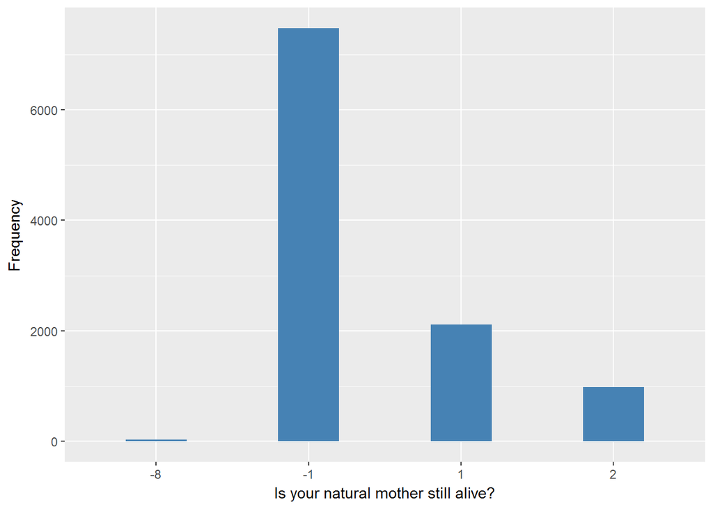

DINFA

| Sample size | Missing values |
| --- | --- |
| 10601 | 8491 |

Category

|  | 1 | 2 |
| --- | --- | --- |
| Frequency | 1014.00 | 1096.00 |
| Percentage | 9.57 | 10.34 |

Type of missing

|  | -9 | -8 | -2 | -1 | NA |
| --- | --- | --- | --- | --- | --- |
| Frequency | 0 | 81.00 | 0 | 8410.00 | 0 |
| Percentage | 0 | 0.76 | 0 | 79.33 | 0 |

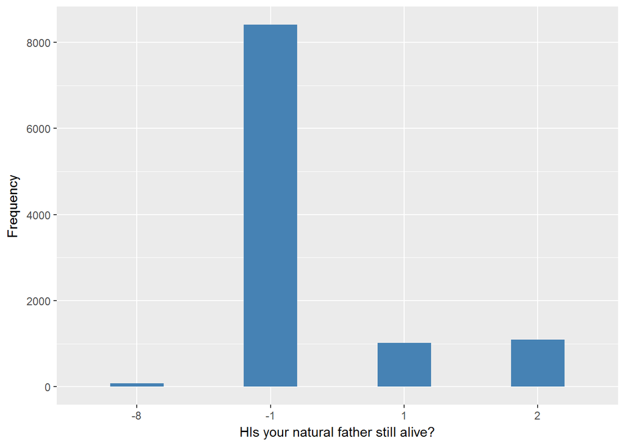

DISIB

| Sample size | Missing values |
| --- | --- |
| 10601 | 32 |

Values

|  | No-missings | -9 | -8 | -1 | NA |
| --- | --- | --- | --- | --- | --- |
| Frequency | 10569.0 | 0 | 13.00 | 19.00 | 0 |
| Percentage | 99.7 | 0 | 0.12 | 0.18 | 0 |

Summary

| Min. | 1st Qu. | Median | Mean | 3rd Qu. | Max. |
| --- | --- | --- | --- | --- | --- |
| 0 | 1 | 1 | 1.86 | 3 | 16 |

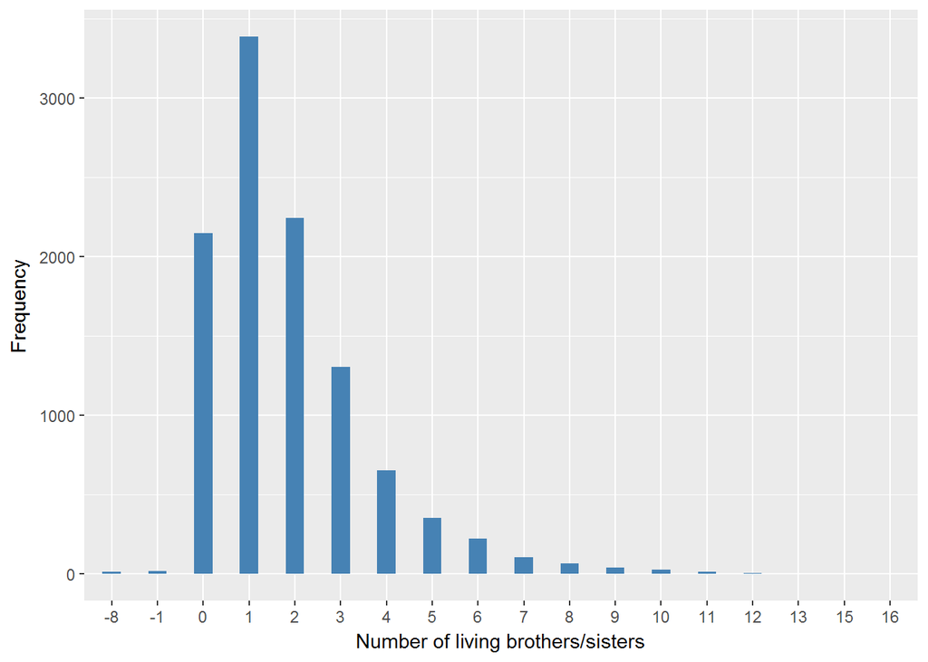

#### 2.1.6.2 Harmonisation algorithm

To recode the harmonize variable from the study-specific variable it has to be recoded as follows:

- `if any eqauls 1 or DiSib>0 then 1`
- `if all are equal 2 and DiSib=0 then 0`
- `-1 or -2 into 996`
- `-8 into 998`
- `-9 into 997, but -9 for scfam into 995`
- `NA into 999`

**R script:**

```r
ELSA_ds_w6 <- tibble(id = ELSA_w6_oth_fam$id)

ELSA_w6_oth_fam$scfam <- car::recode(as.vector(ELSA_w6_oth_fam$scfam), "NA='-999'")
ELSA_w6_oth_fam$DiNFA <- car::recode(as.vector(ELSA_w6_oth_fam$DiNFA), "NA='-999'")
ELSA_w6_oth_fam$DiNMA <- car::recode(as.vector(ELSA_w6_oth_fam$DiNMA), "NA='-999'")
ELSA_w6_oth_fam$DiSib <- car::recode(as.vector(ELSA_w6_oth_fam$DiSib), "NA='-999'")

ELSA_ds_w6$oth_fam <- c(NA)
for (i in 1:dim(ELSA_w6_oth_fam)[1]) {
    if (ELSA_w6_oth_fam$scfam[i] == 1 | ELSA_w6_oth_fam$DiNFA[i] == 1 | ELSA_w6_oth_fam$DiNMA[i] ==
        1 | ELSA_w6_oth_fam$DiSib[i] > 0) {
        ELSA_ds_w6$oth_fam[i] = 1
    } else if (ELSA_w6_oth_fam$scfam[i] == 2 & ELSA_w6_oth_fam$DiNFA[i] %in% c(2,
        -1) & ELSA_w6_oth_fam$DiNMA[i] %in% c(2, -1) & ELSA_w6_oth_fam$DiSib[i] ==
        0) {
        ELSA_ds_w6$oth_fam[i] = 0
    } else if (ELSA_w6_oth_fam$scfam[i] == -8 | ELSA_w6_oth_fam$DiNFA[i] == -8 |
        ELSA_w6_oth_fam$DiNMA[i] == -8 | ELSA_w6_oth_fam$DiSib[i] == -8) {
        ELSA_ds_w6$oth_fam[i] = 998
    } else if (ELSA_w6_oth_fam$scfam[i] == -2 | ELSA_w6_oth_fam$DiNFA[i] == -2 |
        ELSA_w6_oth_fam$DiNMA[i] == -2 | ELSA_w6_oth_fam$DiSib[i] == -2) {
        ELSA_ds_w6$oth_fam[i] = 996
    } else if (ELSA_w6_oth_fam$DiNFA[i] == -9 | ELSA_w6_oth_fam$DiNMA[i] == -9 |
        ELSA_w6_oth_fam$DiSib[i] == -9) {
        ELSA_ds_w6$oth_fam[i] = 997
    } else if (ELSA_w6_oth_fam$scfam[i] == -9) {
        ELSA_ds_w6$oth_fam[i] = 995
    } else if (ELSA_w6_oth_fam$scfam[i] == -1 | ELSA_w6_oth_fam$DiNFA[i] == -1 |
        ELSA_w6_oth_fam$DiNMA[i] == -1 | ELSA_w6_oth_fam$DiSib[i] == -1) {
        ELSA_ds_w6$oth_fam[i] = 996
    }
}

ELSA_ds_w6$oth_fam <- car::recode(as.vector(ELSA_ds_w6$oth_fam), "NA='999'")
ELSA_ds_w6$oth_fam <- labelled(ELSA_ds_w6$oth_fam, labels = c(No = 0, Yes = 1,
    Missing = 999, `Do not know` = 998, Refuse = 997, `Not applicable` = 996,
    `Don't answer` = 995, `Not attempt/not done/not yet recorded` = 994, `Disable to measure` = 993,
    Impute = 992, `CAPI/interviewer error` = 991))
```

#### 2.1.6.3 Statistical description of the new harmonised variable

| Sample size | Missing values |
| --- | --- |
| 10601 | 340 |

Category

|  | 0 | 1 |
| --- | --- | --- |
| Frequency | 500.00 | 9761.00 |
| Percentage | 4.72 | 92.08 |

Type of missing

|  | 991 | 992 | 993 | 994 | 995 | 996 | 997 | 998 | 999 | NA |
| --- | --- | --- | --- | --- | --- | --- | --- | --- | --- | --- |
| Frequency | 0 | 0 | 0 | 0 | 13.00 | 304.00 | 0 | 23.00 | 0 | 0 |
| Percentage | 0 | 0 | 0 | 0 | 0.12 | 2.87 | 0 | 0.22 | 0 | 0 |

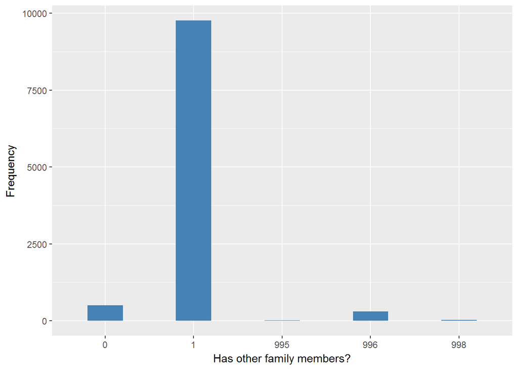